# Исследование данных о продаже игр.

Из открытых источников нам доступны исторические данные о продажах игр, оценки пользователей и экспертов, жанры и платформы. Нам нужно выявить определяющие успешность игры закономерности. Это позволит сделать ставку на потенциально популярный продукт и спланировать рекламные кампании для интернет-магазина «Стримчик», который продаёт по всему миру компьютерные игры. Перед нами данные до 2016 года. Представим, что сейчас декабрь 2016 г., и мы планируем кампанию на 2017-й.

**Цель исследования** - выявить определяющие успешность игры закономерности:

- Выбрать несколько потенциально прибыльных платформ за актуальный период.
- Составить портрет пользователя каждого региона.
- Проверить две гипотезы:
1. О равенстве средних пользовательских рейтингов платформ Xbox One и PC.
2. О неравенстве средних пользовательских рейтингов жанров Action и Sports.

**Ход исследования**

Данные за 2016 год могут быть неполными. Также мы не знаем качество доступных данных. Поэтому понадобится обзор данных.

Проверим данные на ошибки и оценим их влияние на исследование. Затем на этапе предобработки поищем возможность исправить самые критичные ошибки данных. Далее необходимо провести исследовательский анализ данных и перейти непосредственно к главным целям исследования.

Таким образом, исследование пройдет в несколько этапов:

1. Обзор данных
2. Предобработка данных
3. Исследовательский анализ данных, включающий этапы:
- Посмотреть сколько игр выпускалось в разные годы.
- Изучить как менялись продажи по платформам.
- Определить актуальный период , который поможет построить прогноз на 2017 год.
- Выбрать несколько потенциально прибыльных платформ.
- Посмотреть как влияют на продажи внутри одной популярной платформы отзывы пользователей и критиков и соотнести выводы с продажами игр на других платформах.
- Посмотреть на общее распределение игр по жанрам.
1. Составление портрета пользователя каждого региона.
2. Проверка гипотез.

## Обзор данных

Составим первое представление о данных.

```python
import pandas as pd  # Импортируем необходимые библиотеки, прочитаем файл и сохраним его в переменную data.
from matplotlib import pyplot as plt
import seaborn as sns
from scipy import stats as st
import numpy as np

pd.set_option('chained_assignment', None)
```

```python
try:
    data = pd.read_csv('games.csv')
except:
    data = pd.read_csv('/datasets/games.csv')
```

```python
data.head(10) # Выведем первые 10 строк на экран.
```

|  | Name | Platform | Year_of_Release | Genre | NA_sales | EU_sales | JP_sales | Other_sales | Critic_Score | User_Score | Rating |
| --- | --- | --- | --- | --- | --- | --- | --- | --- | --- | --- | --- |
| 0 | Wii Sports | Wii | 2006.0 | Sports | 41.36 | 28.96 | 3.77 | 8.45 | 76.0 | 8 | E |
| 1 | Super Mario Bros. | NES | 1985.0 | Platform | 29.08 | 3.58 | 6.81 | 0.77 | NaN | NaN | NaN |
| 2 | Mario Kart Wii | Wii | 2008.0 | Racing | 15.68 | 12.76 | 3.79 | 3.29 | 82.0 | 8.3 | E |
| 3 | Wii Sports Resort | Wii | 2009.0 | Sports | 15.61 | 10.93 | 3.28 | 2.95 | 80.0 | 8 | E |
| 4 | Pokemon Red/Pokemon Blue | GB | 1996.0 | Role-Playing | 11.27 | 8.89 | 10.22 | 1.00 | NaN | NaN | NaN |
| 5 | Tetris | GB | 1989.0 | Puzzle | 23.20 | 2.26 | 4.22 | 0.58 | NaN | NaN | NaN |
| 6 | New Super Mario Bros. | DS | 2006.0 | Platform | 11.28 | 9.14 | 6.50 | 2.88 | 89.0 | 8.5 | E |
| 7 | Wii Play | Wii | 2006.0 | Misc | 13.96 | 9.18 | 2.93 | 2.84 | 58.0 | 6.6 | E |
| 8 | New Super Mario Bros. Wii | Wii | 2009.0 | Platform | 14.44 | 6.94 | 4.70 | 2.24 | 87.0 | 8.4 | E |
| 9 | Duck Hunt | NES | 1984.0 | Shooter | 26.93 | 0.63 | 0.28 | 0.47 | NaN | NaN | NaN |

```python
data.info() # Получим общую информацию о таблице.
```

```
<class 'pandas.core.frame.DataFrame'>
RangeIndex: 16715 entries, 0 to 16714
Data columns (total 11 columns):
 #   Column           Non-Null Count  Dtype
---  ------           --------------  -----
 0   Name             16713 non-null  object
 1   Platform         16715 non-null  object
 2   Year_of_Release  16446 non-null  float64
 3   Genre            16713 non-null  object
 4   NA_sales         16715 non-null  float64
 5   EU_sales         16715 non-null  float64
 6   JP_sales         16715 non-null  float64
 7   Other_sales      16715 non-null  float64
 8   Critic_Score     8137 non-null   float64
 9   User_Score       10014 non-null  object
 10  Rating           9949 non-null   object
dtypes: float64(6), object(5)
memory usage: 1.4+ MB
```

Итак, в таблице 11 столбцов. Количество значений в столбцах различается. Что подтверждает наличие пропущенных значений в данных. В называниях столбцов видны нарушения стиля, а именно строчные буквы сочетаются с прописными. Согласно документации к данным :

- Name — название игры
- Platform — платформа
- Year_of_Release — год выпуска
- Genre — жанр игры
- NA_sales — продажи в Северной Америке (миллионы проданных копий)
- EU_sales — продажи в Европе (миллионы проданных копий)
- JP_sales — продажи в Японии (миллионы проданных копий)
- Other_sales — продажи в других странах (миллионы проданных копий)
- Critic_Score — оценка критиков (максимум 100)
- User_Score — оценка пользователей (максимум 10)
- Rating — рейтинг от организации ESRB (англ. Entertainment Software Rating Board). Эта ассоциация определяет рейтинг компьютерных игр и присваивает им подходящую возрастную категорию.

Year_of_Release хранит данные в float64, хотя предполагается целочисленный тип для обозначения года. Тип данных в столбце User_Score - object , хотя должен быть float64 так как в столбце оценка пользователя предполагается хранение вещественных чисел.

**Выводы** В каждой строке таблицы данные об играх. Часть колонок описывает параметры непосредственно самих игр. Остальные данные описываю параметры реализации этих игр в виде количества продаж и оценок. В данных встречаются пропуски. Названия всех колонок имеют расхождение с хорошим стилем, а именно строчные буквы сочетаются с прописными, необходимо привести названия к нижнему регистру. Тип данных некоторых столбцов не соответствует требуемому. Необходимо поменять тип данных столбца Year_of_Release с float на Int. В столбце User_Score поменять тип данных с object на float. В столбце rating необходимо проверить разбивку на категориям, на соответсвие реальным данным, переименовать пропущенные значения в unknown, для того, чтобы учесть эти данные при анализе популярных жанров.

## Предобработка данных.

### Приведем названия столбцов в соответствие с хорошим стилем.

```python
data.columns = data.columns.str.lower() # Приведем названия столбцов к нижнему регистру.
```

```python
list(data) # Проверим результат.
```

```
['name',
 'platform',
 'year_of_release',
 'genre',
 'na_sales',
 'eu_sales',
 'jp_sales',
 'other_sales',
 'critic_score',
 'user_score',
 'rating']
```

### Пропуски значений.

Посмотрим сколько в таблице пропущенных значений.

```python
data.isna().agg(['mean', 'sum']).T.sort_values(by='mean', ascending=False)
```

|  | mean | sum |
| --- | --- | --- |
| critic_score | 0.513192 | 8578.0 |
| rating | 0.404786 | 6766.0 |
| user_score | 0.400897 | 6701.0 |
| year_of_release | 0.016093 | 269.0 |
| name | 0.000120 | 2.0 |
| genre | 0.000120 | 2.0 |
| platform | 0.000000 | 0.0 |
| na_sales | 0.000000 | 0.0 |
| eu_sales | 0.000000 | 0.0 |
| jp_sales | 0.000000 | 0.0 |
| other_sales | 0.000000 | 0.0 |

Пропуски в name и genre можно удалить, так как их ничтожно мало. Пропуски значений в year_of_release занимают долю примерно в 1,6%. Мы не можем заменить год релиза на какое-либо логичное значение, поэтому посчитаем нужным удалить эти строки. В столбцах critic_score, rating и user_score наблюдается достаточно большая доля пропусков, примерно: 51%, 40% и 40% соответственно. Удаление строк в в этих столбцах может привести к потере большого количества информации. Тем более эти параметры нужны нам для дальнейшего исследования. Посмотрим сколько строк занимают данные с пропусками во всех этих трех колонках.

```python
# Посмотрим срез с условием :пропуска одновременно в трех проблемных колонках.
data.query("critic_score.isna() & user_score.isna() &  rating.isna()")
```

|  | name | platform | year_of_release | genre | na_sales | eu_sales | jp_sales | other_sales | critic_score | user_score | rating |
| --- | --- | --- | --- | --- | --- | --- | --- | --- | --- | --- | --- |
| 1 | Super Mario Bros. | NES | 1985.0 | Platform | 29.08 | 3.58 | 6.81 | 0.77 | NaN | NaN | NaN |
| 4 | Pokemon Red/Pokemon Blue | GB | 1996.0 | Role-Playing | 11.27 | 8.89 | 10.22 | 1.00 | NaN | NaN | NaN |
| 5 | Tetris | GB | 1989.0 | Puzzle | 23.20 | 2.26 | 4.22 | 0.58 | NaN | NaN | NaN |
| 9 | Duck Hunt | NES | 1984.0 | Shooter | 26.93 | 0.63 | 0.28 | 0.47 | NaN | NaN | NaN |
| 10 | Nintendogs | DS | 2005.0 | Simulation | 9.05 | 10.95 | 1.93 | 2.74 | NaN | NaN | NaN |
| ... | ... | ... | ... | ... | ... | ... | ... | ... | ... | ... | ... |
| 16710 | Samurai Warriors: Sanada Maru | PS3 | 2016.0 | Action | 0.00 | 0.00 | 0.01 | 0.00 | NaN | NaN | NaN |
| 16711 | LMA Manager 2007 | X360 | 2006.0 | Sports | 0.00 | 0.01 | 0.00 | 0.00 | NaN | NaN | NaN |
| 16712 | Haitaka no Psychedelica | PSV | 2016.0 | Adventure | 0.00 | 0.00 | 0.01 | 0.00 | NaN | NaN | NaN |
| 16713 | Spirits & Spells | GBA | 2003.0 | Platform | 0.01 | 0.00 | 0.00 | 0.00 | NaN | NaN | NaN |
| 16714 | Winning Post 8 2016 | PSV | 2016.0 | Simulation | 0.00 | 0.00 | 0.01 | 0.00 | NaN | NaN | NaN |

6621 rows × 11 columns

В итоге мы имеем 6621 строку с пропусками в столбцах critic_score, rating и user_score. Можно сделать вывод, что появление пропусков в этих трех колонках взаимосвязано. Поэтому наличие этих пропусков говорит о том, что они носят неслучайный характер, и скорее всего данные для этих колонок отсутствуют, возможно игры новые, оценки еще не успели проставить. Пропусков в колонке critic_score изначально в количестве 8578, вероятно какие -то пропуска не зависели от их наличия в rating и user_score. И здесь может быть другая причина. Логично заполнить эти данные мы не можем, а удалить строки с пропусками означает расстаться с львиной долей данных, что помешает нашему дальнейшему анализу.

Проверим уникальные значения столбца user_score.

```python
data['user_score'].unique()
```

```
array(['8', nan, '8.3', '8.5', '6.6', '8.4', '8.6', '7.7', '6.3', '7.4',
       '8.2', '9', '7.9', '8.1', '8.7', '7.1', '3.4', '5.3', '4.8', '3.2',
       '8.9', '6.4', '7.8', '7.5', '2.6', '7.2', '9.2', '7', '7.3', '4.3',
       '7.6', '5.7', '5', '9.1', '6.5', 'tbd', '8.8', '6.9', '9.4', '6.8',
       '6.1', '6.7', '5.4', '4', '4.9', '4.5', '9.3', '6.2', '4.2', '6',
       '3.7', '4.1', '5.8', '5.6', '5.5', '4.4', '4.6', '5.9', '3.9',
       '3.1', '2.9', '5.2', '3.3', '4.7', '5.1', '3.5', '2.5', '1.9', '3',
       '2.7', '2.2', '2', '9.5', '2.1', '3.6', '2.8', '1.8', '3.8', '0',
       '1.6', '9.6', '2.4', '1.7', '1.1', '0.3', '1.5', '0.7', '1.2',
       '2.3', '0.5', '1.3', '0.2', '0.6', '1.4', '0.9', '1', '9.7'],
      dtype=object)
```

Обнаружилась аббревиатура 'tbd', которая расшифровывается как To Be Determined, то есть "Будет определено". Соответственно оценка пользователей с этой аббревиатурой в столбце означает, что рейтинг еще не определен. Заменим 'tbd' на 'NaN'.

### Изучим столбец rating.

```python
data['rating'].unique()
```

```
array(['E', nan, 'M', 'T', 'E10+', 'K-A', 'AO', 'EC', 'RP'], dtype=object)
```

В соответсвие с рейтингом ESRB (ознакомиться с ним можно по ссылке https://ru.wikipedia.org/wiki/Entertainment_Software_Rating_Board), рейтинг E-"для всех"-это окончательная версия названия, ранее название звучало как "К-А". В связи с этим мы решили объединить эту категорию под общим названием "Е".

Рейтинг RP -"Rating Pending" или "Рейтинг ожидается" означет, что продукт ожидает присвоения рейтинга, поэтому посчитаем возможным объединить рейтинг RP и пропуски в одну категорию "unknown".

```python
data['rating'] = data['rating'].fillna('unknown') # Заполним пропуски.
```

```python
data['rating'] = data['rating'].replace('RP', 'unknown') # Переименуем RP в unknown.
```

```python
data['rating'] = data['rating'].replace('K-A', 'E') # Переименум К-А в Е.
```

```python
data['rating'].unique() # Проверим, что у нас получилось.
```

```
array(['E', 'unknown', 'M', 'T', 'E10+', 'AO', 'EC'], dtype=object)
```

**Выводы** В данных обнаружено по два пропуска в столбцах name и genre, строки с ними вполне можно удалить. В столбце year_of_release обнаружено 1,6 % пропусков, мы решили удалить строки с этими пропусками, так как заменить год релиза не представляется возможным. Значительное количество пропусков в столбцах critic_score, rating и user_score мы не можем заменить логичными значениями или их восстановить, удалить строки-значит потерять большое количество данных, поэтому решено оставить пропуски. Найденную аббревиатуру 'tbd' в некоторых значениях столбца user_score мы заменим на NaN.

```python
data = data.dropna(subset=['name', 'genre', 'year_of_release']) # Удаляем строки с пропусками в столбцах name и genre.
```

```python
data.isna().agg(['mean', 'sum']).T.sort_values(by='mean', ascending=False) # Проверим данные на пропуски.
```

|  | mean | sum |
| --- | --- | --- |
| critic_score | 0.514534 | 8461.0 |
| user_score | 0.401666 | 6605.0 |
| name | 0.000000 | 0.0 |
| platform | 0.000000 | 0.0 |
| year_of_release | 0.000000 | 0.0 |
| genre | 0.000000 | 0.0 |
| na_sales | 0.000000 | 0.0 |
| eu_sales | 0.000000 | 0.0 |
| jp_sales | 0.000000 | 0.0 |
| other_sales | 0.000000 | 0.0 |
| rating | 0.000000 | 0.0 |

Колонки name, genre и year_of_release от пропусков очищены.

```python
data['user_score'] = data['user_score'].replace('tbd', np.NaN) # Заменим аббревиатуру tbd на NaN.
```

```python
data['user_score'].unique() # Проверим результат.
```

```
array(['8', nan, '8.3', '8.5', '6.6', '8.4', '8.6', '7.7', '6.3', '7.4',
       '8.2', '9', '7.9', '8.1', '8.7', '7.1', '3.4', '5.3', '4.8', '3.2',
       '8.9', '6.4', '7.8', '7.5', '2.6', '7.2', '9.2', '7', '7.3', '4.3',
       '7.6', '5.7', '5', '9.1', '6.5', '8.8', '6.9', '9.4', '6.8', '6.1',
       '6.7', '5.4', '4', '4.9', '4.5', '9.3', '6.2', '4.2', '6', '3.7',
       '4.1', '5.8', '5.6', '5.5', '4.4', '4.6', '5.9', '3.9', '3.1',
       '2.9', '5.2', '3.3', '4.7', '5.1', '3.5', '2.5', '1.9', '3', '2.7',
       '2.2', '2', '9.5', '2.1', '3.6', '2.8', '1.8', '3.8', '0', '1.6',
       '9.6', '2.4', '1.7', '1.1', '0.3', '1.5', '0.7', '1.2', '2.3',
       '0.5', '1.3', '0.2', '0.6', '1.4', '0.9', '1', '9.7'], dtype=object)
```

### Преобразование типов данных.

```python
# Поменяем тип данных колонки year_of_release на целочисленный.
data['year_of_release'] = data['year_of_release'].astype('int')
```

```python
# Поменяем тип данных колонки user_score на числовой вещественный.
data['user_score'] = data['user_score'].astype('float64')
```

```python
data.info() # Проверим результат.
```

```
<class 'pandas.core.frame.DataFrame'>
Int64Index: 16444 entries, 0 to 16714
Data columns (total 11 columns):
 #   Column           Non-Null Count  Dtype
---  ------           --------------  -----
 0   name             16444 non-null  object
 1   platform         16444 non-null  object
 2   year_of_release  16444 non-null  int32
 3   genre            16444 non-null  object
 4   na_sales         16444 non-null  float64
 5   eu_sales         16444 non-null  float64
 6   jp_sales         16444 non-null  float64
 7   other_sales      16444 non-null  float64
 8   critic_score     7983 non-null   float64
 9   user_score       7463 non-null   float64
 10  rating           16444 non-null  object
dtypes: float64(6), int32(1), object(4)
memory usage: 1.4+ MB
```

### Дубликаты.

Проверим датафрейм на явные дубликаты.

```python
data.duplicated().sum()
```

```
0
```

Явных дубликатов мы не выявили.

Проверим столбец genre на неявные дубликаты. Выведем список уникальных значений этого столбца.

```python
data['genre'].unique()
```

```
array(['Sports', 'Platform', 'Racing', 'Role-Playing', 'Puzzle', 'Misc',
       'Shooter', 'Simulation', 'Action', 'Fighting', 'Adventure',
       'Strategy'], dtype=object)
```

Неявных дубликатов мы не выявили.

### Посчитаем суммарные продажи во всех регионах и запишем их в отдельный столбец.

```python
# Для этого в новый столбец мы запишем сумму проданных копий, во всех регионах для каждой игры.
data['total_sales'] = data['na_sales'] + data['eu_sales'] + data['jp_sales'] + data['other_sales']
```

**Выводы** Предобработка обнаружила: * Нарушения в стиле заголовков * Пропущенные значения * Значения с аббревиатурой, означающей, что значение еще не определено * Несоответствие типов данных представленным значениям Мы исправили заголовки, приведя все названия к нижнему регистру, чтобы упростить работу с таблицей. В столбцах с небольшим количеством пропущенных значений мы удалили строки с их наличием. Столбцы с большим количесвтом пропусков мы не стали трогать, так как это может привести к некорректному анализу в дальнейшем. Значения с аббревиатурой мы заменили на NaN, чтобы упростить работу со значениями в этом столбце. Типы данных мы преобразовали в соответствующие значениям. Мы создали новый столбец с суммарными продажами млн копий во всех регионах.

## Исследовательский анализ данных.

### Посмотрим, сколько игр выпускалось в разные годы.

```python
# создадим переменную с данными, сгруппированными по году выпуска
years_group = data.groupby('year_of_release')['name'].count().reset_index().rename(columns={'name':'games_count'})
```

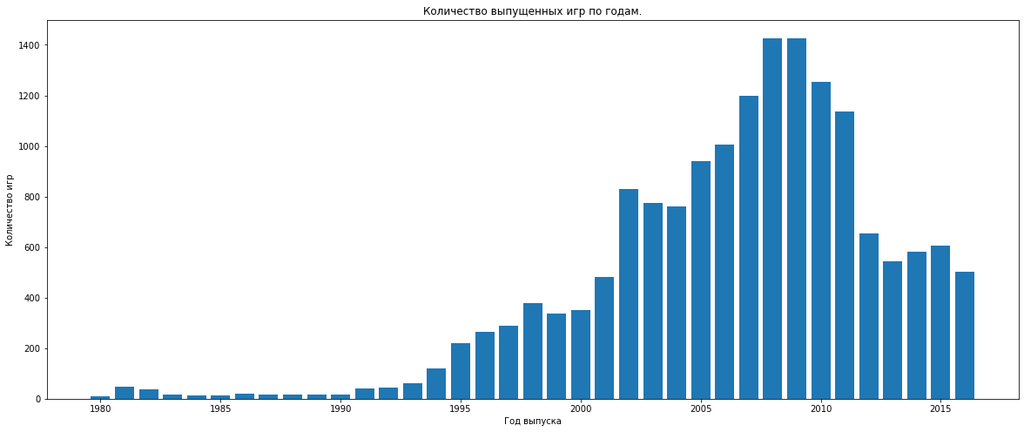

```python
# построим столбчатый график
plt.figure(figsize=(20, 8))
plt.bar(x=years_group['year_of_release'], height=years_group['games_count'])
plt.title('Количество выпущенных игр по годам.')
plt.xlabel('Год выпуска')
plt.ylabel('Количество игр')
plt.show()
```

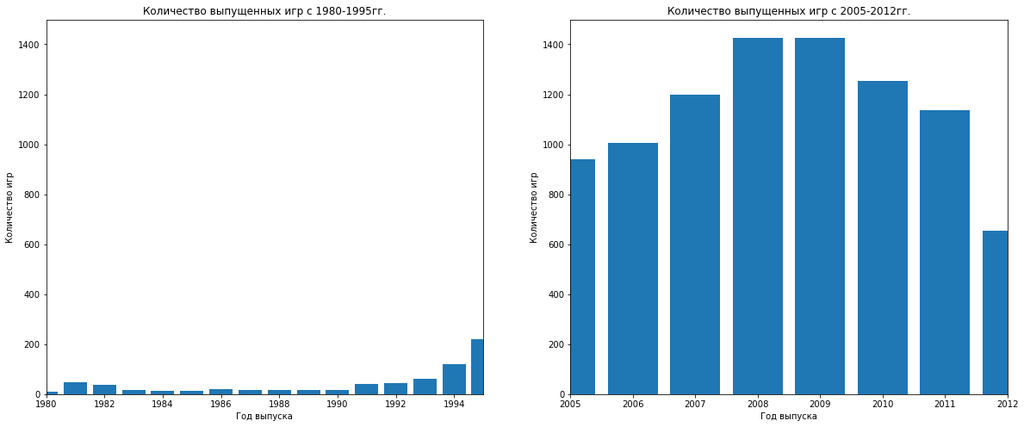

```python
# Пронаблюдаем показатели в интересующих диапазонах.
fig, (ax1, ax2) = plt.subplots(1,2,figsize=(20,8))
ax1.bar(x=years_group['year_of_release'], height=years_group['games_count'])
ax1.set_title('Количество выпущенных игр c 1980-1995гг.')
ax1.set_xlabel('Год выпуска')
ax1.set_ylabel('Количество игр')
ax1.set_xlim([1980, 1995])


ax2.bar(x=years_group['year_of_release'], height=years_group['games_count'])
ax2.set_title('Количество выпущенных игр c 2005-2012гг.')
ax2.set_xlabel('Год выпуска')
ax2.set_ylabel('Количество игр')
ax2.set_xlim([2005, 2012])

plt.show()
```

График показывает, что игры начали выпускать с 1980 года, ощутимый рост производства игр по сравнению с предыдущим периодом, начался с 1994 года. Наблюдается пик производства игр 2008-2009 годах. С 2005 по 2011 года выпускалось больше игр, чем за предыдущие и последующие периоды.

### Посмотрим как менялись продажи по платформам.

Для начала выберем платформы с наибольшими суммарными продажами.

```python
platform_group = data.groupby('platform')['total_sales'].sum().sort_values(ascending=False)
platform_group.head(10)
```

```
platform
PS2     1233.56
X360     961.24
PS3      931.34
Wii      891.18
DS       802.78
PS       727.58
PS4      314.14
GBA      312.88
PSP      289.53
3DS      257.81
Name: total_sales, dtype: float64
```

Выделим топ-6 платформ, со значительным перевесом относительно остальных результатов и построим распределение по годам.

```python
top6_platforms = data[data['platform'].isin(['PS2', 'X360', 'PS3', 'Wii', 'DS', 'PS'])].groupby(['platform', 'year_of_release']).agg(sales=('total_sales', 'sum')).reset_index()
```

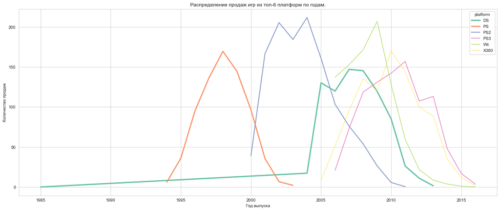

```python
# построим линейный график распределения продаж по годам среди топ-6 платформ
plt.figure(figsize=(20, 8))
sns.set_style('whitegrid')
sns.set_palette('Set2')
sns.lineplot(data=top6_platforms, x='year_of_release', y='sales', hue='platform', size='platform')
plt.title('Распределение продаж игр из топ-6 платформ по годам.')
plt.xlabel('Год выпуска')
plt.ylabel('Количество продаж')
plt.show()
```

График платформы DS не соответствует реальным данным, год выхода платформы-2004. Следует удалить значения до 2004 года.

```python
# Посмотрим на аномальные значения.
data[(data['platform'] == "DS") & (data['year_of_release'] < 2004)]
```

|  | name | platform | year_of_release | genre | na_sales | eu_sales | jp_sales | other_sales | critic_score | user_score | rating | total_sales |
| --- | --- | --- | --- | --- | --- | --- | --- | --- | --- | --- | --- | --- |
| 15957 | Strongest Tokyo University Shogi DS | DS | 1985 | Action | 0.0 | 0.0 | 0.02 | 0.0 | NaN | NaN | unknown | 0.02 |

Всего одна строчка ее можно удалить, чтобы график выглядел правдободобнее.

```python
data = data.drop(15957)
```

```python
# Обновим переменную.
top6_platforms = data[data['platform'].isin(['PS2', 'X360', 'PS3', 'Wii', 'DS', 'PS'])].groupby(['platform', 'year_of_release']).agg(sales=('total_sales', 'sum')).reset_index()
```

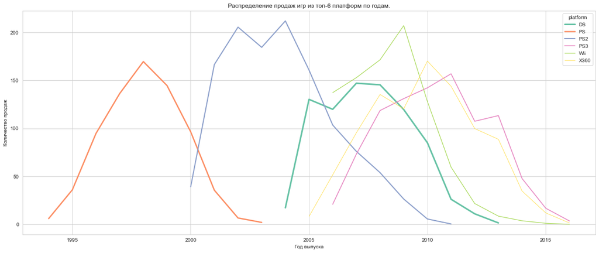

```python
plt.figure(figsize=(20, 8))
sns.set_style('whitegrid')
sns.set_palette('Set2')
sns.lineplot(data=top6_platforms, x='year_of_release', y='sales', hue='platform', size='platform')
plt.title('Распределение продаж игр из топ-6 платформ по годам.')
plt.xlabel('Год выпуска')
plt.ylabel('Количество продаж')
plt.show()
```

**Вывод**

Исходя из полученного графика, можно сделать выводы:

- "Разгон" платфоры до пика продаж ее игр составляет около пяти лет.
- В общем платформа "живет" около 10 лет.
- В целом наблюдается спад выпуска компьютерных игр с 2010 года.

На основании предыдущих исследований можно примерно определить актуальный период для того, чтобы построить прогноз на 2017 год. За период, предшествующий анализу, прослеживается тенденция к снижению выпуска компьютерных игр. Можно ориентироваться на среднюю продолжительность существования платформ и исходя из этого сделать вывод, что актуальным периодом можно выбрать 4 последних года, так как если даже в худшем случае популярные платформы станут терять популярность, на 2017 год они еще точно будут в тренде, так как в среднем спад идет в течении пяти лет. А начинающие набирать популярность платформы, как раз-таки будут на пике своего развития. Данные за 2016 год могут быть неполными по условию, поэтому можно рассмотреть период в 5 лет, то есть с 2012 года.

### Выберем несколько потенциально прибыльных платформ.

```python
actual_period_data = data.query('year_of_release >= 2012')
```

```python
actual_platforms = actual_period_data.groupby(['platform', 'year_of_release']).agg(sales=('total_sales', 'sum')).reset_index()
actual_platforms['platform'].unique()
```

```
array(['3DS', 'DS', 'PC', 'PS3', 'PS4', 'PSP', 'PSV', 'Wii', 'WiiU',
       'X360', 'XOne'], dtype=object)
```

За период с 2012 года представлены данные 11 платформ, построим график распределения их продаж.

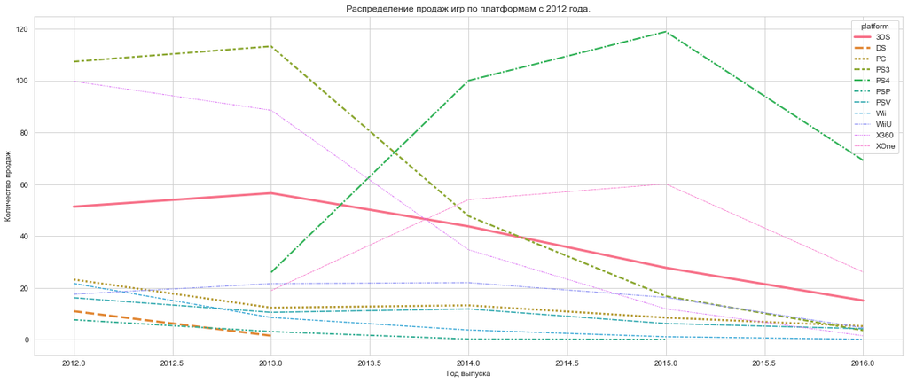

```python
# Построим линейный график распределения продаж по годам за актуальный период среди платформ.
plt.figure(figsize=(20, 8))
sns.set_style('whitegrid')
sns.set_palette('Set2')
sns.lineplot(data=actual_platforms, x='year_of_release', y='sales', hue='platform', size='platform', style='platform')
plt.title('Распределение продаж игр по платформам c 2012 года.')
plt.xlabel('Год выпуска')
plt.ylabel('Количество продаж')
plt.show()
```

График показфывает тенденцию к снижению продаж для всех платформ. Наиболее хорошая картина складывается для платформы PS4, это связано с тем, что она появилась сравнительно недавно, в отличие от остальных платформ. Похожая картина наблюдается у платформы XOne, но продажи меньше, чем у PS4. Можно выделить платформу 3DS, как третью потенциально прибыльную платформу. На 2017 год скорее всего ее потенциала хватит. Но не более, так как линия графика стремится в сторону уменьшения продаж. Можно выделить еще две платформы с похожими друг на друга графиками: PC и PSV. Для продаж этих платформ характерно плавное снижение, и вполне вероятно, что в 2017 году они сравняются с 3DC. Остальные варианты графиков либо чересчур резко идут к снижению, либо плавно, но уже практически стремятся к нулю.

**Вывод** Мы выделили 5 потенциально прибыльных платформ: 1. PS4 2. XOne 3. 3DS 4. PC 5. PSV

```python
top5_platforms = actual_period_data[actual_period_data['platform'].isin(['PS4','XOne','3DS','PC','PSV'])]
top5_platforms.tail()
```

|  | name | platform | year_of_release | genre | na_sales | eu_sales | jp_sales | other_sales | critic_score | user_score | rating | total_sales |
| --- | --- | --- | --- | --- | --- | --- | --- | --- | --- | --- | --- | --- |
| 16699 | The Longest 5 Minutes | PSV | 2016 | Action | 0.0 | 0.0 | 0.01 | 0.0 | NaN | NaN | unknown | 0.01 |
| 16703 | Strawberry Nauts | PSV | 2016 | Adventure | 0.0 | 0.0 | 0.01 | 0.0 | NaN | NaN | unknown | 0.01 |
| 16707 | Aiyoku no Eustia | PSV | 2014 | Misc | 0.0 | 0.0 | 0.01 | 0.0 | NaN | NaN | unknown | 0.01 |
| 16712 | Haitaka no Psychedelica | PSV | 2016 | Adventure | 0.0 | 0.0 | 0.01 | 0.0 | NaN | NaN | unknown | 0.01 |
| 16714 | Winning Post 8 2016 | PSV | 2016 | Simulation | 0.0 | 0.0 | 0.01 | 0.0 | NaN | NaN | unknown | 0.01 |

```python
top5_platforms['total_sales'].describe()
```

```
count    1696.000000
mean        0.459847
std         1.146474
min         0.010000
25%         0.030000
50%         0.100000
75%         0.350000
max        14.630000
Name: total_sales, dtype: float64
```

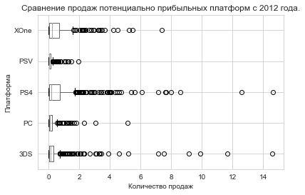

```python
# построим диаграммы размаха для прибыльных платформ, не учитывая отдельные выбросы после отметки 5 по оси y
top5_platforms.boxplot(column='total_sales', by='platform', vert=False)
plt.title('Сравнение продаж потенциально прибыльных платформ с 2012 года.')
plt.xlabel('Количество продаж')
plt.ylabel('Платформа')
plt.suptitle('')
plt.show()
```

Мы увидели некоторое количество очень больших значений продаж, с максимумом 14,63 особенно в сравнении с медианами, среднее которых колеблется в районе 0,1 млн копий. Посмотрим на наши диаграммы после отсечения выбросов от 4 млн копий.

Перезапишем переменные с актуальными данными.

```python
actual_period_data = actual_period_data.query('total_sales <= 4')
```

```python
top5_platforms = actual_period_data[actual_period_data['platform'].isin(['PS4','XOne','3DS','PC','PSV'])]
```

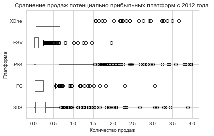

```python
top5_platforms.boxplot(column='total_sales', by='platform', vert=False)
plt.title('Сравнение продаж потенциально прибыльных платформ с 2012 года.')
plt.xlabel('Количество продаж')
plt.ylabel('Платформа')
plt.suptitle('')
plt.show()
```

Медианы всех пяти платформ находятся в педелах от 0,05-0,25 млн копий, расположены по-разному. Медианы продаж у платформ XOne и PS4 лидируют, также разброс значений выше медианы значительно шире, чем у других боксплотов, и большинство значений достигают предела в 1,5 млн копий, а это значит, что и значения с более высокими продажами присущи этим двум платформам. Наименьшее значение медианы наблюдается у платформы PSV, также ей характерен небольшой разброс данных, аккумулированных до 0,25 млн копий и ее медиана лежит в пределах 0,05 млн копий.

**Вывод**

После отсечения выбросов, сравнение диаграм размаха показало, что XOne лидирует по медиане продаж. Зато у PS4 много высоких значений за пределами нормальных значений. В целом их диграммы выглядят схоже.

Выявилось, что продажи платформы PCV, хоть и вели себя похоже на линейном графике с продажами платформы PC, в сравнительном графике боксплотов выглядят разительно хуже продаж своих "конкурентов". Поэтому посчитаем нужным убрать из рейтинга пятую платформу PSV.

Поэтому список топ-4 потенциально прибыльных платформ выгдядит так:

1. XOne
2. PS4
3. 3DS
4. PC

### Посмотрим, как влияют на продажи внутри одной популярной платформы отзывы пользователей и критиков.

```python
XOne_platform = actual_period_data.query('platform == "XOne"') # создадим срез по интересующей нас платформе
```

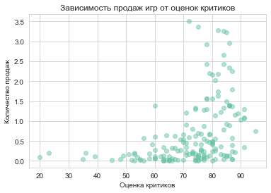

```python
# построим диаграмму рассеяния для зависимости продаж игр от оценки критиков
plt.scatter(XOne_platform['critic_score'], XOne_platform['total_sales'], alpha = 0.5)
plt.title('Зависимость продаж игр от оценок критиков')
plt.xlabel('Оценка критиков')
plt.ylabel('Количество продаж')
plt.show()
```

Заметно очень слабое скопление сочетаний параметров в промежутке от 70 до 80 баллов в оценке. Возможно небольшая корреляция присутствует. Необходимо ее рассчитать.

```python
print('Коэффициент корреляции равен: ', XOne_platform['total_sales'].corr(XOne_platform['critic_score']))
```

```
Коэффициент корреляции равен:  0.40247317540796723
```

Как и предполагалась, результат показал среднюю положительную корреляцию. Это значит, что чем выше оценка критиков, тем вероятнее, что продажи увеличиваются.

Теперь посмотрим диаграмму рассеяния и коэффициент корреляции для зависимости между оценкой пользователей и продажами игр.

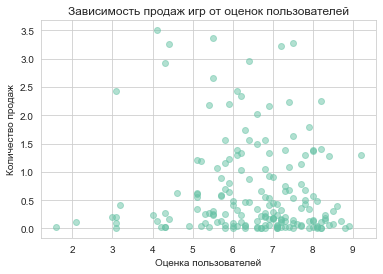

```python
# построим диаграмму рассеяния для зависимости продаж игр от оценки пользователей
plt.scatter(XOne_platform['user_score'], XOne_platform['total_sales'], alpha = 0.5)
plt.title('Зависимость продаж игр от оценок пользователей')
plt.xlabel('Оценка пользователей')
plt.ylabel('Количество продаж')
plt.show()
```

Наблюдается очень небольшое скопление сочетаний параметров. Возможно предположить либо отсутствие либо наличие очень слабой корреляции.

```python
print('Коэффициент корреляции равен: ', XOne_platform['user_score'].corr(XOne_platform['total_sales']))
```

```
Коэффициент корреляции равен:  -0.0869883196639842
```

Коэффициент практически стремится к нулю, для XOne платформы зависимости продаж от оценок пользователей практически нет.

Теперь рассмотрим влияли ли оценки на продажи на других платформах из нашего топ-4 списка.

```python
PS4_platform = data.query('platform == "PS4"') # Создадим срезы по интересующим нас платформам.
DS_platform = data.query('platform == "3DS"')
PC_platform = data.query('platform == "PC"')
```

```python
print(PS4_platform[['critic_score', 'user_score', 'total_sales' ]].corr())
```

```
              critic_score  user_score  total_sales
critic_score      1.000000    0.557654     0.406568
user_score        0.557654    1.000000    -0.031957
total_sales       0.406568   -0.031957     1.000000
```

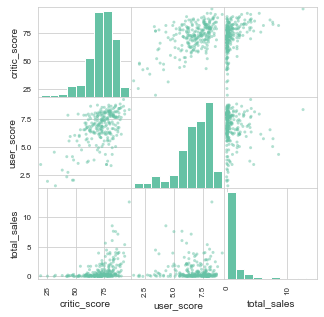

```python
pd.plotting.scatter_matrix(PS4_platform[['critic_score', 'user_score', 'total_sales']], figsize=(5, 5));
```

```python
print(DS_platform[['critic_score', 'user_score', 'total_sales' ]].corr())
```

```
              critic_score  user_score  total_sales
critic_score      1.000000    0.745222     0.348740
user_score        0.745222    1.000000     0.222078
total_sales       0.348740    0.222078     1.000000
```

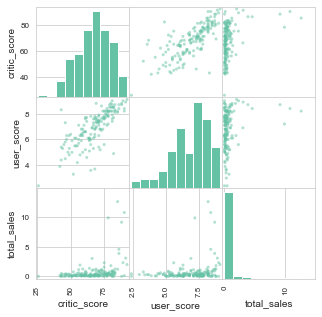

```python
pd.plotting.scatter_matrix(DS_platform[['critic_score', 'user_score', 'total_sales']], figsize=(5, 5));
```

```python
print(PC_platform[['critic_score', 'user_score', 'total_sales' ]].corr())
```

```
              critic_score  user_score  total_sales
critic_score      1.000000    0.555199     0.257395
user_score        0.555199    1.000000     0.012905
total_sales       0.257395    0.012905     1.000000
```

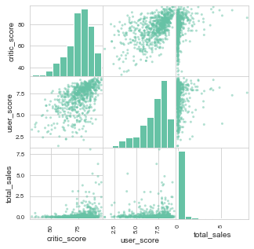

```python
pd.plotting.scatter_matrix(PC_platform[['critic_score', 'user_score', 'total_sales']], figsize=(5, 5));
```

В среднем наблюдается достаточно высокая корреляция между оценками критиков и оценками пользователей. Однако, оценки критиков хоть как-то влияют на продажи, коррелирую с ними на 0,25-0,4, а на оценки пользователей покупатели почти не ориентируются, судя по низким коэффициентам корреляции от -0,08 - 0,23. Можно выделить только платформу 3DS , где присутствует слабая положительная корреляция между оценками пользователей и продажами.

**Вывод**

Исходя из проведенного анализа на нахождение взимосвязи между оценками и продажами игр среди топ-4 предположительно прибыльных платформ, мы выяснили, что покупатели ориентируются на оценки критиков при покупке игр, но очень редко опираются на оценки пользователей.

### Посмотрим на общее распределение игр по жанрам.

Для визуализации удобно использовать круговую диаграмму.

```python
top4_platforms = actual_period_data[actual_period_data['platform'].isin(['PS4','XOne','3DS','PC'])] # Обновим наш топ.
```

```python
# создадим сводную таблицу для графика
good_top4_platforms = top4_platforms.pivot_table(index = 'genre', values = 'total_sales', aggfunc = 'median').reset_index().sort_values(ascending=False, by = 'total_sales')
```

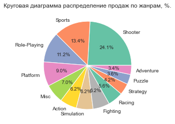

```python
plt.pie(good_top4_platforms['total_sales'], labels=good_top4_platforms['genre'], autopct='%.1f%%')
plt.title('Круговая диаграмма распределение продаж по жанрам, %.')
plt.show()
```

**Вывод**

- Shooter
- Sports
- Role_Playing
- Platform

Выделяется жанр Shooter как самый продаваемый, ему принадлежат около 24 % всех медианных продаж.

Самые низкие продажи до 4 % у каждого жанра от общего количества медианных продаж принадлежат жанрам Adventure, Puzzle.

### Составим портрет пользователя каждого региона.

#### Определим топ-5 самых популярных платформ по каждому региону.

Распределение продаж по платформам в Северной Америке.

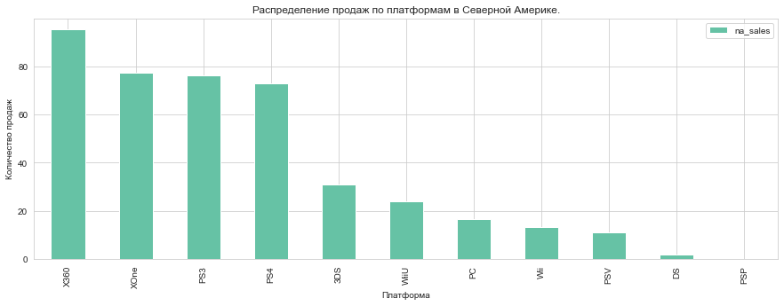

```python
# Построим стобчатый график на основе сводной таблицы
na_group = actual_period_data.pivot_table(index = 'platform', values = 'na_sales', aggfunc = 'sum').sort_values(by='na_sales', ascending=False)
(
    na_group
    .plot(kind = 'bar',
       figsize=(15,5),
       ylabel='na_sales',
       title='Распределение продаж по платформам в Северной Америке.',
       grid=True
      )
)
plt.xlabel('Платформа')
plt.ylabel('Количество продаж')
plt.show()
```

```python
na_group['share'] = na_group['na_sales']/na_group['na_sales'].sum()*100
na_group
```

| platform | na_sales | share |
| --- | --- | --- |
| X360 | 95.15 | 22.695831 |
| XOne | 77.21 | 18.416659 |
| PS3 | 76.21 | 18.178132 |
| PS4 | 72.83 | 17.371911 |
| 3DS | 30.97 | 7.387177 |
| WiiU | 23.88 | 5.696021 |
| PC | 16.68 | 3.978628 |
| Wii | 13.40 | 3.196260 |
| PSV | 10.98 | 2.619025 |
| DS | 1.80 | 0.429348 |
| PSP | 0.13 | 0.031008 |

Топ-5 платформ в Северной Америке принадлежит Х360, XOne, PS4, PS3 и 3DS, что характерно, два первых места занимают игры на американские консоли-на их долю приходится около 40 % продаж. Далее 3 места топ-пятерки распределяются между японскими производителями, которые не отстают и в купе занимают 40 с лишним % продаж. Также можно отметить, что американцы предпочитают игровые приставки портативным консолям.

Проведем подобный анализ для продаж в Европе.

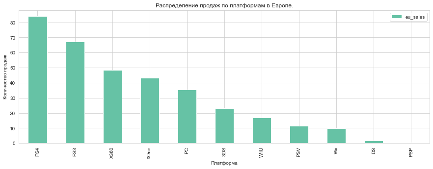

```python
# Построим стобчатый график на основе сводной таблицы
eu_group = actual_period_data.pivot_table(index = 'platform', values = 'eu_sales', aggfunc = 'sum').sort_values(by='eu_sales', ascending=False)
(
    eu_group
    .plot(kind = 'bar',
       figsize=(15,5),
       ylabel='eu_sales',
       title='Распределение продаж по платформам в Европе.',
       grid=True)
)
plt.xlabel('Платформа')
plt.ylabel('Количество продаж')
plt.show()
```

```python
eu_group['share'] = eu_group['eu_sales']/eu_group['eu_sales'].sum()*100
eu_group
```

| platform | eu_sales | share |
| --- | --- | --- |
| PS4 | 83.95 | 24.551809 |
| PS3 | 67.14 | 19.635598 |
| X360 | 48.49 | 14.181265 |
| XOne | 43.15 | 12.619542 |
| PC | 35.60 | 10.411488 |
| 3DS | 23.14 | 6.767467 |
| WiiU | 17.11 | 5.003948 |
| PSV | 11.36 | 3.322317 |
| Wii | 9.76 | 2.854385 |
| DS | 1.81 | 0.529348 |
| PSP | 0.42 | 0.122832 |

Топ-5 платформ в Европе принадлежат PS4, PS3, X360, ХOne и PC, что характерно, приоритеты уже другие, первые два места принадлежат играм на японские консоли, третье и четвертое места на американские, замыкают пятерку игры на пк. Также можно отметить, что европейцы предпочитают игровые приставки портативным консолям.

Анализ для продаж в Японии.

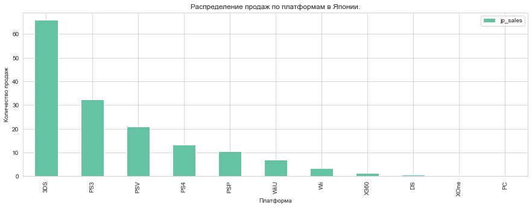

```python
# Построим стобчатый график на основе сводной таблицы
jp_group=actual_period_data.pivot_table(index = 'platform', values = 'jp_sales', aggfunc = 'sum').sort_values(by='jp_sales', ascending=False)
(
    jp_group
    .plot(kind = 'bar',
       figsize=(15,5),
       ylabel='jp_sales',
       title='Распределение продаж по платформам в Японии.',
       grid=True
      )
)
plt.xlabel('Платформа')
plt.ylabel('Количество продаж')
plt.show()
```

```python
jp_group['share'] = jp_group['jp_sales']/jp_group['jp_sales'].sum()*100
jp_group
```

| platform | jp_sales | share |
| --- | --- | --- |
| 3DS | 65.78 | 42.318580 |
| PS3 | 32.41 | 20.850489 |
| PSV | 21.04 | 13.535769 |
| PS4 | 13.22 | 8.504889 |
| PSP | 10.47 | 6.735718 |
| WiiU | 7.00 | 4.503345 |
| Wii | 3.39 | 2.180906 |
| X360 | 1.27 | 0.817036 |
| DS | 0.58 | 0.373134 |
| XOne | 0.28 | 0.180134 |
| PC | 0.00 | 0.000000 |

С заметным отрывом лидирует 3DS, далее PS3, PSV, PS4 и замыкает пятерку PSP. Можно с уверенностью сказать, что японцы очень патриотичны в выборе консолей. Кроме того стал очевиден факт того, что японцы предпочитают портативные платформы.

#### Рассмотрим самые популярные жанры среди тех же трех регионов.

```python
genre_sales_na = actual_period_data.pivot_table(index='genre', values='na_sales', aggfunc='sum').reset_index().sort_values(by='na_sales', ascending=False)
genre_sales_na.loc[genre_sales_na['na_sales'] < 22, 'genre'] = 'other'
```

```python
genre_sales_eu = actual_period_data.pivot_table(index='genre', values='eu_sales', aggfunc='sum').reset_index().sort_values(by='eu_sales', ascending=False)
genre_sales_eu.loc[genre_sales_eu['eu_sales'] < 25, 'genre']='other'
```

```python
genre_sales_jp = actual_period_data.pivot_table(index='genre', values='jp_sales', aggfunc='sum').reset_index().sort_values(by='jp_sales', ascending=False)
genre_sales_jp.loc[genre_sales_jp['jp_sales'] < 7, 'genre']='other'
```

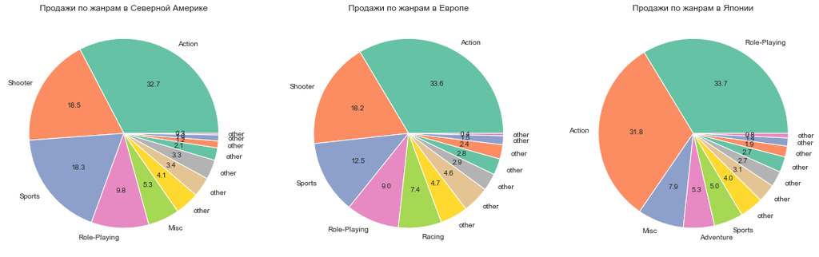

```python
fig, (ax1, ax2, ax3) = plt.subplots(1,3, figsize=(20,7))
ax1.pie(genre_sales_na['na_sales'], autopct='%1.1f', labels=genre_sales_na['genre'])
ax1.set_title('Продажи по жанрам в Северной Америке')
ax2.pie(genre_sales_eu['eu_sales'], autopct='%1.1f', labels=genre_sales_eu['genre'])
ax2.set_title('Продажи по жанрам в Европе')
ax3.pie(genre_sales_jp['jp_sales'], autopct='%1.1f', labels=genre_sales_jp['genre'])
ax3.set_title('Продажи по жанрам в Японии')
plt.show()
```

Судя по диаграммам, вкусы на жанры в Северной Америке и Европе очень схожи. Более 30 % суммарных продаж в этих регионах приходится на Action. Далее три места занимают игры жанров Shooter, Sports и Role_Playing. Единственное жанровое отличие в топ-5 это то, что в Северной Америке предпочитают Misc, а в Европе Racing.

Что касается Японии, то огромную популярность у них имеют Role-Playing игры и Action. Далее расположился Misc, Adventure, Sports.

#### Проверим влияет ли рейтинг ESRB на продажи в отдельном регионе.

Для этого мы сагрегируем данные продаж по сумме по каждому региону в отдельности и построим диаграммы.

```python
esrb_sales_na = actual_period_data.pivot_table(index='rating', values='na_sales', aggfunc='sum').reset_index().sort_values(by='na_sales', ascending=False)
```

```python
esrb_sales_eu = actual_period_data.pivot_table(index='rating', values='eu_sales', aggfunc='sum').reset_index().sort_values(by='eu_sales', ascending=False)
```

```python
esrb_sales_jp = actual_period_data.pivot_table(index='rating', values='jp_sales', aggfunc='sum').reset_index().sort_values(by='jp_sales', ascending=False)
```

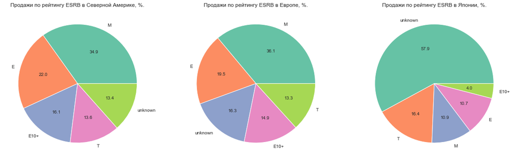

```python
fig, (ax1, ax2, ax3) = plt.subplots(1,3, figsize=(20,7))
ax1.pie(esrb_sales_na['na_sales'], autopct='%1.1f', labels=esrb_sales_na['rating'])
ax1.set_title('Продажи по рейтингу ESRB в Северной Америке, %.')
ax2.pie(esrb_sales_eu['eu_sales'], autopct='%1.1f', labels=esrb_sales_eu['rating'])
ax2.set_title('Продажи по рейтингу ESRB в Европе, %.')
ax3.pie(esrb_sales_jp['jp_sales'], autopct='%1.1f', labels=esrb_sales_jp['rating'])
ax3.set_title('Продажи по рейтингу ESRB в Японии, %.')
plt.show()
```

Для того, чтобы яснее увидеть картину, посмотрим медианные продажи по регионам.

```python
esrb_sales_na_med = actual_period_data.pivot_table(index='rating', values='na_sales', aggfunc='median').reset_index().sort_values(by='na_sales', ascending=False)
```

```python
esrb_sales_eu_med = actual_period_data.pivot_table(index='rating', values='eu_sales', aggfunc='median').reset_index().sort_values(by='eu_sales', ascending=False)
```

```python
esrb_sales_jp_med = actual_period_data.pivot_table(index='rating', values='jp_sales', aggfunc='median').reset_index().sort_values(by='jp_sales', ascending=False)
```

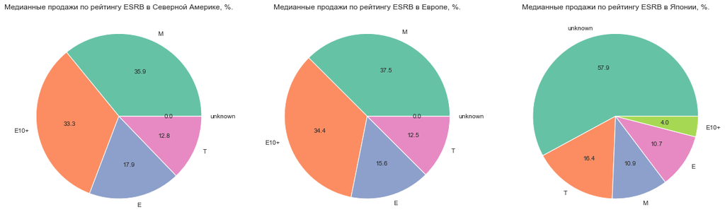

```python
fig, (ax1, ax2, ax3) = plt.subplots(1,3, figsize=(20,7))
ax1.pie(esrb_sales_na_med['na_sales'], autopct='%1.1f', labels=esrb_sales_na_med['rating'])
ax1.set_title('Медианные продажи по рейтингу ESRB в Северной Америке, %.')
ax2.pie(esrb_sales_eu_med['eu_sales'], autopct='%1.1f', labels=esrb_sales_eu_med['rating'])
ax2.set_title('Медианные продажи по рейтингу ESRB в Европе, %.')
ax3.pie(esrb_sales_jp['jp_sales'], autopct='%1.1f', labels=esrb_sales_jp['rating'])
ax3.set_title('Медианные продажи по рейтингу ESRB в Японии, %.')
plt.show()
```

И снова мы видим относительное единодушие в процентном соотношении покупаемых игр в зависимости от рейтинга ESRB в Северной Америке и Европе. По сумме продаж побеждают игры, которые не подходят для лиц младше 17 лет (М). И далее мы видим примерно одинаковые доли, приходящиеся на остальные жанры.

Что касается Японии, то всего 10 % приходится на игры, которые не подходят для лиц младше 17 лет(М), что совершенно не коррелирует с диаграммами остальных двух регионов. Также возможно отметить большой процент продаж игр-около 58% из категории unknown, приходящийся на японский рынок. Возможно это связано с тем, что в Японии покупаются игры с рейтингом, проставленным своей рейтинговой организацией, поэтому очень много продаж попало под категорию unknown именно в разрезе продаж по Японии.

**Вывод**

Типичный пользователь игр в Европе очень схож по характеристикам с пользвателем в Северной Америке. Мы также выявили интерес к игровым приставкам, в домашней обстановке играть предпочтительней. Наблюдаются сходства и в предпочтениях в жанрах, но есть и различие в топ-5-это жанр Racing вместо Misc в Америке. Похожая ситуация и с покупаемостью рейтингов-М и Е10+ также в топе.

### Проверим гипотезы.

#### Гипотеза о равенстве средних пользовательских рейтингов платформ Xbox One и РС.

Нулевая гипотеза: средний пользовательский рейтинг платформы Xbox One равен среднему пользовательскому рейтингу PC.

Альтернативная гипотеза: средний пользовательский рейтинг платформы Xbox One не равен среднему пользовательскому рейтингу PC.

```python
Xbox_array = actual_period_data[(actual_period_data['platform'] == 'XOne') & (actual_period_data['user_score'] > 0)]['user_score']
Xbox_array.mean()
```

```
6.522471910112357
```

```python
PC_array = actual_period_data[(actual_period_data['platform'] == 'PC') & (actual_period_data['user_score'] > 0)]['user_score']
PC_array.mean()
```

```
6.440487804878046
```

```python
Xbox_array.dropna().shape
```

```
(178,)
```

```python
PC_array.dropna().shape
```

```
(205,)
```

Средние выборок немного отличаются, для дополнительной проверки гипотезы о равенстве среднего двух генеральных совокупностей по взятым из них выборкам мы будем использовать метод ttest_ind.

```python
alpha = .05

results = st.ttest_ind(
Xbox_array.dropna(),
PC_array.dropna(),
)

print('p-значение:', results.pvalue)

if results.pvalue < alpha:
    print("Отвергаем нулевую гипотезу")
else:
    print("Не получилось отвергнуть нулевую гипотезу")
```

```
p-значение: 0.6036863027755537
Не получилось отвергнуть нулевую гипотезу
```

Посчитав средние значения наших выборок, мы обнаружили, что они немного отличаются, но проведя тест, мы не смогли отвергнуть нулевую гипотезу об их равенстве, это значит, что различия посчитанных средних были скорее всего случайны.

#### Гипотеза о различие средних пользовательских рейтингов жанров Action и Sports.

Нулевая гипотеза: средний пользовательский рейтинг жанра Action равен среднему пользовательскому рейтингу жанра Sports.

Альтернативная гипотеза: средний пользовательский рейтинг жанра Action не равен среднему пользовательскому рейтингу жанра Sports.

```python
action_array = actual_period_data[(actual_period_data['genre'] == 'Action') &  (actual_period_data['user_score'] > 0)]['user_score']
action_array.mean()
```

```
6.807827788649717
```

```python
sports_array = actual_period_data[(actual_period_data['genre'] == 'Sports') &  (actual_period_data['user_score'] > 0)]['user_score']
sports_array.mean()
```

```
5.48095238095238
```

```python
action_array.shape
```

```
(511,)
```

```python
sports_array.shape
```

```
(189,)
```

Средние выборок по расчетам действительно не равны, необходимо дополнительно утвердится во мнении с помощью дополнительной проверки гипотезы о равенстве среднего двух генеральных совокупностей по взятым из них выборкам. Мы будем использовать метод ttest_ind. Также учтем параметр equal_var, так как размеры выборок значительно различаются.

```python
alpha = .05

results = st.ttest_ind(
action_array,
sports_array,
equal_var=False
)

print('p-значение:', results.pvalue)

if results.pvalue < alpha:
    print("Отвергаем нулевую гипотезу")
else:
    print("Не получилось отвергнуть нулевую гипотезу")
```

```
p-значение: 2.671235022080325e-18
Отвергаем нулевую гипотезу
```

У нас получилось отвергнуть нулевую гипотезу о равенстве средних пользовательских рейтингов жанров Action и Sports. Вероятность получить одинаковые средние ничтожно мала.

**Вывод**

Прежде чем перейти к анализу, мы провели предобработку данных:

- Удалили строки с пропусками, по возможности заменили пропуски там, где они могли бы помешать анализу.
- Переименовали столбцы в соответствии с хорошим стилем.
- Поменяли типы данных на соответствующие логике типы.
- В столбце rating скорректировали разбивку по категориям, в соответствии с актуальными данными.
- Значения с аббревиатурой tbd ("будет определено") мы заменили на NaN, чтобы упростить работу со значениями в этом столбце.
- Создали новый столбец с суммарными продажами игр в млн копий во всех регионах.

Мы выяснили, что игры начали выпускать с 1980 года, и ощутимый рост производства игр по сравнению с предыдущим периодом, начался с 1994 года. Наблюдается пик производства игр 2008-2009 годах. Далее наблюдается спад продаж игр на консоли.

Мы определили примерный срок жизни платформы около 10 лет. Также на основании этого наблюдения выделили акьуальный период рассмотрения данных для нащей задачи- 5 лет(с 2012 г).

Далее мы выделили 4 потенциально прибыльные платформы за выделенный актуальный период:

1. PS4
2. XOne
3. 3DS
4. PC

Мы выяснили, что чем выше оценка критиков, тем больше продажи игры.

Мы составили портрет пользователя каждого региона.

Типичный пользователь игр в Северной Америке предпочитает игровые приставки портативным консолям. Отечественные и японские производители пользуются практически одинаковой популярностью среди покупателей. Стоит отметить, что в Северной Америке очень популярны активные жанры игр Action, Shooter, Sports и Role_Playing. Особенно активно покупают игры с рейтингом М (не подходят для лиц младше 17 лет) и Е10+ (рейтингом от 10 лет и старше).

Типичный пользователь игр в Европе очень схож по характеристикам с пользвателем в Северной Америке. Мы также выявили интерес к игровым приставкам, в домашней обстановке играть предпочтительней. Наблюдаются сходства и в предпочтениях в жанрах, наблюдается различие в топ-5-это жанр Racing вместо Misc в Америке. Похожая ситуация и с покупаемостью рейтингов-М и Е10+ также в топе.

Типичный покупатель игр в Японии отличается коренным образом от западных регионов. Топ-5 самых продаваемых платформ принадлежит японским компаниям. Стоит отметить, что японцы очень активно пользуются портативными консолями. В топ-5 вошли игры жанров Role-Playing, Action, Misc, Adventure и Sports.

Что касается влияния рейтинга ESRB, то ситуация не ясна, около 58 % проданных игр приходится на неопределеннный рейтинг поэтому сделать какие-либо выводы не предоставляется возможным.

Подведя итог, можно сделать вывод, что для каждого региона необходимо предусмотреть свои индивидуальные критерии выбора игр. Мы решили по возможности учитывать интересы японских пользователей, но за основу взять предпочтения западных регионов.

Если рассматривать в общем эти регионы, то рекомендуется выбрать две платформы: PS4 и XOne как одни из самых потенциально прибыльных. Также игры жанров Action, Shooter, Role-Playing, Sports рекомендованы к продаже. Особенно активно покупают игры с рейтингом М (не подходят для лиц младше 17 лет) и Е10+ (рейтингом от 10 лет и старше).